# Introduction

The objective of this project is to develop models capable of accurately predicting whether an email is likely to be a spam and/or phishing attempt or a legitimate communication. Phishing and spam attacks represent a significant and growing threat in the cybersecurity landscape, through these attacks users can be deceived into clicking on malicious links that could compromise personal information or install malware on their systems. The models developed below are capable of analyzing the email’s text and domain of the embedded link. Using machine learning, I aimed to create a solution that could classify emails as either spam, phishing or safe with a high degree of accuracy.

The models used include, the ChatGPT-4 LLM and four machine learning models, Logistic Regression, Gradient Boosting, Decision Trees, and Random Forest Classifier were tested and evaluated to determine the most effective algorithm for spam and phishing email detection. The ChatGPT-4 LLM was selected due to its processing capabilities, the Logistic models were chosen for their ability to handle classification tasks and their varying strengths in handling complex data relationships.

# Loading Libraries

```python
import pandas as pd
import numpy as np
import matplotlib.pyplot as plt
import seaborn as sns
import sweetviz as sv
import json
from pandas import json_normalize

# Scikit-learn imports
from sklearn.model_selection import train_test_split, GridSearchCV, RandomizedSearchCV, cross_val_score
from sklearn.preprocessing import StandardScaler, LabelEncoder
from sklearn.metrics import mean_absolute_error, mean_squared_error, accuracy_score, precision_score, recall_score, f1_score, classification_report, confusion_matrix, roc_auc_score, roc_curve, r2_score
from sklearn.svm import SVR
from sklearn.ensemble import RandomForestRegressor, RandomForestClassifier, GradientBoostingClassifier
from sklearn.linear_model import LogisticRegression
from sklearn.naive_bayes import GaussianNB
from sklearn.datasets import load_iris, make_classification
from sklearn.tree import DecisionTreeClassifier

# OpenAI imports
import openai
from openai import OpenAI
import tiktoken

from IPython.display import HTML
```

# Loading Datasets

```python
pd.reset_option('display.max_rows')
pd.set_option('display.width', None)
```

```python
# SOURCE: https://www.kaggle.com/datasets/joebeachcapital/phiusiil-phishing-url
file_path = 'Phishing_Dataset_2.csv'
Phishing = pd.read_csv(file_path)
```

```python
# SOURCE: https://www.kaggle.com/datasets/venky73/spam-mails-dataset
file_path = 'spam_ham_dataset.csv'
Emails = pd.read_csv(file_path)
```

# Spam Checker Model Implementation With ChatGPT

```python
client = OpenAI(
    api_key="XXXXX",
)
```

## Emails EDA

Note: The main variable of focus is the label and label_num variable, label=ham and label_num=0 is safe, label=spam and label_num=1 is spam.

```python
Emails.head(5)
```

|  | Unnamed: 0 | label | text | label_num |
| --- | --- | --- | --- | --- |
| 0 | 605 | ham | Subject: enron methanol ; meter # : 988291\r\n... | 0 |
| 1 | 2349 | ham | Subject: hpl nom for january 9 , 2001\r\n( see... | 0 |
| 2 | 3624 | ham | Subject: neon retreat\r\nho ho ho , we ' re ar... | 0 |
| 3 | 4685 | spam | Subject: photoshop , windows , office . cheap ... | 1 |
| 4 | 2030 | ham | Subject: re : indian springs\r\nthis deal is t... | 0 |

```python
Emails.columns
```

```
Index(['Unnamed: 0', 'label', 'text', 'label_num'], dtype='object')
```

```python
Emails.isna().sum()
```

```
Unnamed: 0    0
label         0
text          0
label_num     0
dtype: int64
```

```python
Emails["label_num"].value_counts()
```

```
label_num
0    3672
1    1499
Name: count, dtype: int64
```

```python
Emails_Spam=Emails[Emails['label'] == "spam"]
Emails_Spam["text"].apply(len).describe()
```

```
count     1499.000000
mean      1223.256171
std       1825.986210
min         11.000000
25%        283.000000
50%        576.000000
75%       1253.500000
max      22073.000000
Name: text, dtype: float64
```

```python
Emails_Not_Spam=Emails[Emails['label'] == "ham"]
Emails_Not_Spam["text"].apply(len).describe()
```

```
count     3672.000000
mean       977.008170
std       1382.827493
min         18.000000
25%        231.750000
50%        530.000000
75%       1227.250000
max      32258.000000
Name: text, dtype: float64
```

## Assembling Email Training Datasets

```python
def count_tokens(text):
    encoding = tiktoken.get_encoding("cl100k_base")
    tokens = encoding.encode(text)
    return len(tokens)
```

```python
Email_training_data_spam=Emails[Emails['label'] == "spam"].sample(n=5)
Email_training_data_ham=Emails[Emails['label'] == "ham"].sample(n=5)
Email_training_dataset=pd.concat([Email_training_data_spam,Email_training_data_ham])
Email_training_dataset=Email_training_dataset.sample(frac=1).reset_index(drop=True)

Email_training_dataset=Email_training_dataset.drop(columns=["Unnamed: 0","label"])

while(count_tokens(Email_training_dataset['text'].str.cat(sep=''))>4000):
    Email_training_data_spam=Emails[Emails['label'] == "spam"].sample(n=5)
    Email_training_data_ham=Emails[Emails['label'] == "ham"].sample(n=5)
    Email_training_dataset=pd.concat([Email_training_data_spam,Email_training_data_ham])
    Email_training_dataset=Email_training_dataset.sample(frac=1).reset_index(drop=True)
```

```python
Email_training_dataset
```

|  | text | label_num |
| --- | --- | --- |
| 0 | Subject: liffe is great\r\nhello ,\r\nvlsit ou... | 1 |
| 1 | Subject: cruise 3 nts mexico only $ 197 ! - - ... | 1 |
| 2 | Subject: defs purchase of teco pipeline\r\neff... | 0 |
| 3 | Subject: hpl nom for january 13 , 2001\r\n( se... | 0 |
| 4 | Subject: equistar feb - 01\r\ni think i found ... | 0 |
| 5 | Subject: eshopkey + ??????????? !\r\n?? eshopk... | 1 |
| 6 | Subject: bowl games\r\nhi ,\r\n?\r\nam i to un... | 0 |
| 7 | Subject: re [ 9 ]\r\nhotbot wallpapers the x -... | 1 |
| 8 | Subject: neon lesson # 6\r\n- experiencing god... | 0 |
| 9 | Subject: need low priced software ? tess arrow... | 1 |

## Assembling Email Testing Datasets

```python
Email_testing_data_spam=Emails[Emails['label'] == "spam"].sample(n=5)
Email_testing_data_ham=Emails[Emails['label'] == "ham"].sample(n=5)
Email_testing_dataset=pd.concat([Email_testing_data_spam,Email_testing_data_ham])
Email_testing_dataset=Email_testing_dataset.sample(frac=1).reset_index(drop=True)

while(count_tokens(Email_testing_dataset['text'].str.cat(sep=''))>4000):
    Email_testing_data_spam=Emails[Emails['label'] == "spam"].sample(n=9)
    Email_testing_data_ham=Emails[Emails['label'] == "ham"].sample(n=9)
    Email_testing_dataset=pd.concat([Email_testing_data_spam,Email_testing_data_ham])
    Email_testing_dataset=Email_testing_dataset.sample(frac=1).reset_index(drop=True)
    Email_validation_dataset=Email_testing_dataset
Email_validation_dataset=Email_testing_dataset
Email_testing_dataset=Email_testing_dataset.drop(columns=["Unnamed: 0","label","label_num"])
```

```python
Email_testing_dataset
```

|  | text |
| --- | --- |
| 0 | Subject: el paso cuts to oasis\r\nfyi\r\n6 / 8... |
| 1 | Subject: lonestar payback for 31 st\r\nfyi - -... |
| 2 | Subject: network cable tester and free ! rj - ... |
| 3 | Subject: shopping for [ mortgages ] made easy\... |
| 4 | Subject: you prescription number 66\r\nsup cos... |
| 5 | Subject: 17 mens and 81 womans die from aiw .\... |
| 6 | Subject: lyz balk filters ? - forget xof 8 ttb... |
| 7 | Subject: hpl nom for july 14 , 2000 revision #... |
| 8 | Subject: marathon oil company meter 098 - 6599... |
| 9 | Subject: re : kcs buy / sell\r\nlauri ,\r\nhpl... |

## Assembling Email Validation Dataset

```python
Email_validation_dataset
```

|  | Unnamed: 0 | label | text | label_num |
| --- | --- | --- | --- | --- |
| 0 | 949 | ham | Subject: el paso cuts to oasis\r\nfyi\r\n6 / 8... | 0 |
| 1 | 1533 | ham | Subject: lonestar payback for 31 st\r\nfyi - -... | 0 |
| 2 | 4286 | spam | Subject: network cable tester and free ! rj - ... | 1 |
| 3 | 4089 | spam | Subject: shopping for [ mortgages ] made easy\... | 1 |
| 4 | 5141 | spam | Subject: you prescription number 66\r\nsup cos... | 1 |
| 5 | 3770 | spam | Subject: 17 mens and 81 womans die from aiw .\... | 1 |
| 6 | 3757 | spam | Subject: lyz balk filters ? - forget xof 8 ttb... | 1 |
| 7 | 1183 | ham | Subject: hpl nom for july 14 , 2000 revision #... | 0 |
| 8 | 3299 | ham | Subject: marathon oil company meter 098 - 6599... | 0 |
| 9 | 2371 | ham | Subject: re : kcs buy / sell\r\nlauri ,\r\nhpl... | 0 |

## Performing Text Analysis Training and Testing With ChatGPT 4.0

```python
for index, row in Email_testing_dataset.iterrows():
    response = client.chat.completions.create(
        model="gpt-4",
        messages=[
            {"role": "system", "content": "You are an Email Spam Detector. You will be provided a JSON list of sample labeled emails, the labels are 0 for not spam and 1 for spam. After being provided the training list, you will be provided a dataset to label if it is spam or not."},
            {"role": "system", "content": "Provide answers in JSON format with no line space included. THe JSON headers will be label_num(only 0 and 1 is acceptable), confidence(0 to 1) and reasoning. You will provide exactly 1 JSON row in response to each question and will adhere to the mentioned heaaders"},
            {"role": "system", "content": f"The following is the training data: {Email_training_dataset.to_json()}, no response is needed for this, this is just for you to learn so don't reply to this"},
            {"role": "user", "content": f"The following is the data you will analyze and respond to: {row["text"]}"}
        ]
    )
    js = json.loads(response.choices[0].message.content)

    df_js=json_normalize(js)

    Email_testing_dataset.at[index, 'ChatGPT Label Guess'] = df_js['label_num'].values[0]
    Email_testing_dataset.at[index, 'confidence'] = df_js['confidence'].values[0]
    Email_testing_dataset.at[index, 'reasoning'] = df_js['reasoning'].values[0]
```

### Printing Result

```python
Email_testing_dataset
```

|  | text | ChatGPT Label Guess | confidence | reasoning |
| --- | --- | --- | --- | --- |
| 0 | Subject: el paso cuts to oasis\r\nfyi\r\n6 / 8... | 0.0 | 0.80 | This email appears to be part of a business-re... |
| 1 | Subject: lonestar payback for 31 st\r\nfyi - -... | 0.0 | 0.97 | The email is discussing business related trans... |
| 2 | Subject: network cable tester and free ! rj - ... | 1.0 | 0.93 | This email contains significant features indic... |
| 3 | Subject: shopping for [ mortgages ] made easy\... | 1.0 | 0.90 | The email contains various signs of being spam... |
| 4 | Subject: you prescription number 66\r\nsup cos... | 1.0 | 0.95 | The email contains key indicators of spam such... |
| 5 | Subject: 17 mens and 81 womans die from aiw .\... | 1.0 | 0.60 | The email appears unstructured, including a ra... |
| 6 | Subject: lyz balk filters ? - forget xof 8 ttb... | 1.0 | 0.95 | The suspicious phrasing, speed and volume of d... |
| 7 | Subject: hpl nom for july 14 , 2000 revision #... | 0.0 | 0.97 | The email is associated with a specific workin... |
| 8 | Subject: marathon oil company meter 098 - 6599... | 0.0 | 0.99 | This email is related to a business transactio... |
| 9 | Subject: re : kcs buy / sell\r\nlauri ,\r\nhpl... | 0.0 | 0.98 | The email is discussing business-related tasks... |

## ChatGpt Spam Detector Model Accuracy Score

```python
(Email_validation_dataset["label_num"] == Email_testing_dataset["ChatGPT Label Guess"]).mean() * 100
```

```
100.0
```

# Phishing Detector Models

## EDA

Note: The main variable of focus is the Phishing variable, 1 is for Safe link and 0 is for a Phishing link

### EDA Before Dropping Columns

#### Dataset columns

As an inital step a feature named qty_slash_url was added to the dataset. This column counts the number of slashes in the url.

```python
Phishing.shape
```

```
(235795, 57)
```

```python
Phishing.dtypes
```

```
Phishing                        int64
FILENAME                       object
URL                            object
URLLength                       int64
Domain                         object
DomainLength                    int64
IsDomainIP                      int64
TLD                            object
URLSimilarityIndex            float64
CharContinuationRate          float64
TLDLegitimateProb             float64
URLCharProb                   float64
TLDLength                       int64
NoOfSubDomain                   int64
HasObfuscation                  int64
NoOfObfuscatedChar              int64
ObfuscationRatio              float64
NoOfLettersInURL                int64
LetterRatioInURL              float64
NoOfDegitsInURL                 int64
DegitRatioInURL               float64
NoOfEqualsInURL                 int64
NoOfQMarkInURL                  int64
NoOfAmpersandInURL              int64
NoOfOtherSpecialCharsInURL      int64
SpacialCharRatioInURL         float64
IsHTTPS                         int64
LineOfCode                      int64
LargestLineLength               int64
HasTitle                        int64
Title                          object
DomainTitleMatchScore         float64
URLTitleMatchScore            float64
HasFavicon                      int64
Robots                          int64
IsResponsive                    int64
NoOfURLRedirect                 int64
NoOfSelfRedirect                int64
HasDescription                  int64
NoOfPopup                       int64
NoOfiFrame                      int64
HasExternalFormSubmit           int64
HasSocialNet                    int64
HasSubmitButton                 int64
HasHiddenFields                 int64
HasPasswordField                int64
Bank                            int64
Pay                             int64
Crypto                          int64
HasCopyrightInfo                int64
NoOfImage                       int64
NoOfCSS                         int64
NoOfJS                          int64
NoOfSelfRef                     int64
NoOfEmptyRef                    int64
NoOfExternalRef                 int64
qty_url_slashes                 int64
dtype: object
```

```python
Phishing.dtypes.value_counts()
```

```
int64      42
float64    10
object      5
Name: count, dtype: int64
```

```python
Phishing.info()
```

```
<class 'pandas.core.frame.DataFrame'>
RangeIndex: 235795 entries, 0 to 235794
Data columns (total 57 columns):
 #   Column                      Non-Null Count   Dtype
---  ------                      --------------   -----
 0   Phishing                    235795 non-null  int64
 1   FILENAME                    235795 non-null  object
 2   URL                         235795 non-null  object
 3   URLLength                   235795 non-null  int64
 4   Domain                      235795 non-null  object
 5   DomainLength                235795 non-null  int64
 6   IsDomainIP                  235795 non-null  int64
 7   TLD                         235795 non-null  object
 8   URLSimilarityIndex          235795 non-null  float64
 9   CharContinuationRate        235795 non-null  float64
```

[output cut: 49 more lines]

```python
Phishing["Phishing"].value_counts()
```

```
Phishing
1    134850
0    100945
Name: count, dtype: int64
```

```python
Phishing.describe()
```

|  | Phishing | URLLength | DomainLength | IsDomainIP | URLSimilarityIndex | CharContinuationRate | TLDLegitimateProb | URLCharProb | TLDLength | NoOfSubDomain | ... | Pay | Crypto | HasCopyrightInfo | NoOfImage | NoOfCSS | NoOfJS | NoOfSelfRef | NoOfEmptyRef | NoOfExternalRef | qty_url_slashes |
| --- | --- | --- | --- | --- | --- | --- | --- | --- | --- | --- | --- | --- | --- | --- | --- | --- | --- | --- | --- | --- | --- |
| count | 235795.000000 | 235795.000000 | 235795.000000 | 235795.000000 | 235795.000000 | 235795.000000 | 235795.000000 | 235795.000000 | 235795.000000 | 235795.000000 | ... | 235795.000000 | 235795.000000 | 235795.000000 | 235795.000000 | 235795.000000 | 235795.000000 | 235795.000000 | 235795.000000 | 235795.000000 | 235795.000000 |
| mean | 0.571895 | 34.573095 | 21.470396 | 0.002706 | 78.430778 | 0.845508 | 0.260423 | 0.055747 | 2.764456 | 1.164758 | ... | 0.237007 | 0.023474 | 0.486775 | 26.075689 | 6.333111 | 10.522305 | 65.071113 | 2.377629 | 49.262516 | 0.429314 |
| std | 0.494805 | 41.314153 | 9.150793 | 0.051946 | 28.976055 | 0.216632 | 0.251628 | 0.010587 | 0.599739 | 0.600969 | ... | 0.425247 | 0.151403 | 0.499826 | 79.411815 | 74.866296 | 22.312192 | 176.687539 | 17.641097 | 161.027430 | 1.003464 |
| min | 0.000000 | 13.000000 | 4.000000 | 0.000000 | 0.155574 | 0.000000 | 0.000000 | 0.001083 | 2.000000 | 0.000000 | ... | 0.000000 | 0.000000 | 0.000000 | 0.000000 | 0.000000 | 0.000000 | 0.000000 | 0.000000 | 0.000000 | 0.000000 |
| 25% | 0.000000 | 23.000000 | 16.000000 | 0.000000 | 57.024793 | 0.680000 | 0.005977 | 0.050747 | 2.000000 | 1.000000 | ... | 0.000000 | 0.000000 | 0.000000 | 0.000000 | 0.000000 | 0.000000 | 0.000000 | 0.000000 | 1.000000 | 0.000000 |
| 50% | 1.000000 | 27.000000 | 20.000000 | 0.000000 | 100.000000 | 1.000000 | 0.079963 | 0.057970 | 3.000000 | 1.000000 | ... | 0.000000 | 0.000000 | 0.000000 | 8.000000 | 2.000000 | 6.000000 | 12.000000 | 0.000000 | 10.000000 | 0.000000 |
| 75% | 1.000000 | 34.000000 | 24.000000 | 0.000000 | 100.000000 | 1.000000 | 0.522907 | 0.062875 | 3.000000 | 1.000000 | ... | 0.000000 | 0.000000 | 1.000000 | 29.000000 | 8.000000 | 15.000000 | 88.000000 | 1.000000 | 57.000000 | 1.000000 |
| max | 1.000000 | 6097.000000 | 110.000000 | 1.000000 | 100.000000 | 1.000000 | 0.522907 | 0.090824 | 13.000000 | 10.000000 | ... | 1.000000 | 1.000000 | 1.000000 | 8956.000000 | 35820.000000 | 6957.000000 | 27397.000000 | 4887.000000 | 27516.000000 | 34.000000 |

8 rows × 52 columns

```python
Phishing=Phishing.drop('FILENAME',axis=1)
```

### Data Pre processing

#### Printing Head

```python
Phishing.head(10)
```

|  | Phishing | URL | URLLength | Domain | DomainLength | IsDomainIP | TLD | URLSimilarityIndex | CharContinuationRate | TLDLegitimateProb | ... | Pay | Crypto | HasCopyrightInfo | NoOfImage | NoOfCSS | NoOfJS | NoOfSelfRef | NoOfEmptyRef | NoOfExternalRef | qty_url_slashes |
| --- | --- | --- | --- | --- | --- | --- | --- | --- | --- | --- | --- | --- | --- | --- | --- | --- | --- | --- | --- | --- | --- |
| 0 | 0 | industrialplotsncr.com | 29 | industrialplotsncr.com | 22 | 0 | com | 100.0 | 1.0 | 0.522907 | ... | 0 | 0 | 0 | 0 | 0 | 0 | 0 | 0 | 0 | 0 |
| 1 | 0 | kbcwinneers.com | 22 | kbcwinneers.com | 15 | 0 | com | 100.0 | 1.0 | 0.522907 | ... | 0 | 0 | 0 | 0 | 0 | 0 | 1 | 0 | 1 | 0 |
| 2 | 0 | eildonrealestate.com | 28 | eildonrealestate.com | 20 | 0 | com | 100.0 | 1.0 | 0.522907 | ... | 0 | 0 | 0 | 1 | 1 | 4 | 0 | 0 | 0 | 0 |
| 3 | 0 | prupim.com | 17 | prupim.com | 10 | 0 | com | 100.0 | 1.0 | 0.522907 | ... | 0 | 0 | 0 | 0 | 0 | 0 | 1 | 0 | 1 | 0 |
| 4 | 0 | midgleyspublichouse.com | 31 | midgleyspublichouse.com | 23 | 0 | com | 100.0 | 1.0 | 0.522907 | ... | 0 | 0 | 0 | 0 | 1 | 3 | 0 | 0 | 0 | 0 |
| 5 | 0 | franciscopereira.com/ | 28 | franciscopereira.com | 20 | 0 | com | 100.0 | 1.0 | 0.522907 | ... | 0 | 0 | 0 | 1 | 1 | 1 | 1 | 0 | 1 | 1 |
| 6 | 1 | www.wealthmagik.com | 26 | www.wealthmagik.com | 19 | 0 | com | 100.0 | 1.0 | 0.522907 | ... | 0 | 0 | 1 | 48 | 54 | 65 | 212 | 0 | 300 | 0 |
| 7 | 1 | www.orderhive.com | 24 | www.orderhive.com | 17 | 0 | com | 100.0 | 1.0 | 0.522907 | ... | 1 | 0 | 1 | 74 | 32 | 37 | 139 | 0 | 165 | 0 |
| 8 | 1 | www.nooneliterecruitment.com | 35 | www.nooneliterecruitment.com | 28 | 0 | com | 100.0 | 1.0 | 0.522907 | ... | 0 | 0 | 1 | 28 | 2 | 9 | 55 | 0 | 66 | 0 |
| 9 | 1 | www.amaranthineblooms.com | 32 | www.amaranthineblooms.com | 25 | 0 | com | 100.0 | 1.0 | 0.522907 | ... | 1 | 0 | 1 | 23 | 43 | 21 | 139 | 0 | 20 | 0 |

10 rows × 56 columns

#### Determining String Variables

```python
StringColumnPhishing=Phishing.select_dtypes(include='object')
StringColumnPhishing.columns
```

```
Index(['URL', 'Domain', 'TLD', 'Title'], dtype='object')
```

#### Encoding Relevant String Variables

```python
from sklearn.preprocessing import LabelEncoder

encoder = LabelEncoder()
Phishing['TLD'] = encoder.fit_transform(Phishing['TLD'])
```

#### Determing Numerical Variables

```python
NumericColumnsPhishing=Phishing.select_dtypes(include='number')
```

```python
NumericColumnsPhishing.head(10)
```

|  | Phishing | URLLength | DomainLength | IsDomainIP | TLD | URLSimilarityIndex | CharContinuationRate | TLDLegitimateProb | URLCharProb | TLDLength | ... | Pay | Crypto | HasCopyrightInfo | NoOfImage | NoOfCSS | NoOfJS | NoOfSelfRef | NoOfEmptyRef | NoOfExternalRef | qty_url_slashes |
| --- | --- | --- | --- | --- | --- | --- | --- | --- | --- | --- | --- | --- | --- | --- | --- | --- | --- | --- | --- | --- | --- |
| 0 | 0 | 29 | 22 | 0 | 231 | 100.0 | 1.0 | 0.522907 | 0.059697 | 3 | ... | 0 | 0 | 0 | 0 | 0 | 0 | 0 | 0 | 0 | 0 |
| 1 | 0 | 22 | 15 | 0 | 231 | 100.0 | 1.0 | 0.522907 | 0.059617 | 3 | ... | 0 | 0 | 0 | 0 | 0 | 0 | 1 | 0 | 1 | 0 |
| 2 | 0 | 28 | 20 | 0 | 231 | 100.0 | 1.0 | 0.522907 | 0.069742 | 3 | ... | 0 | 0 | 0 | 1 | 1 | 4 | 0 | 0 | 0 | 0 |
| 3 | 0 | 17 | 10 | 0 | 231 | 100.0 | 1.0 | 0.522907 | 0.056202 | 3 | ... | 0 | 0 | 0 | 0 | 0 | 0 | 1 | 0 | 1 | 0 |
| 4 | 0 | 31 | 23 | 0 | 231 | 100.0 | 1.0 | 0.522907 | 0.053808 | 3 | ... | 0 | 0 | 0 | 0 | 1 | 3 | 0 | 0 | 0 | 0 |
| 5 | 0 | 28 | 20 | 0 | 231 | 100.0 | 1.0 | 0.522907 | 0.068045 | 3 | ... | 0 | 0 | 0 | 1 | 1 | 1 | 1 | 0 | 1 | 1 |
| 6 | 1 | 26 | 19 | 0 | 231 | 100.0 | 1.0 | 0.522907 | 0.056128 | 3 | ... | 0 | 0 | 1 | 48 | 54 | 65 | 212 | 0 | 300 | 0 |
| 7 | 1 | 24 | 17 | 0 | 231 | 100.0 | 1.0 | 0.522907 | 0.064461 | 3 | ... | 1 | 0 | 1 | 74 | 32 | 37 | 139 | 0 | 165 | 0 |
| 8 | 1 | 35 | 28 | 0 | 231 | 100.0 | 1.0 | 0.522907 | 0.069822 | 3 | ... | 0 | 0 | 1 | 28 | 2 | 9 | 55 | 0 | 66 | 0 |
| 9 | 1 | 32 | 25 | 0 | 231 | 100.0 | 1.0 | 0.522907 | 0.067275 | 3 | ... | 1 | 0 | 1 | 23 | 43 | 21 | 139 | 0 | 20 | 0 |

10 rows × 53 columns

#### Determining correlation of numerical variables to the main Phishing Variable

```python
correlation_matrix = NumericColumnsPhishing.corr()
top_10_corr=correlation_matrix['Phishing'].sort_values()
```

```python
 top_10_corr
```

```
SpacialCharRatioInURL        -0.533537
qty_url_slashes              -0.494489
DegitRatioInURL              -0.432032
LetterRatioInURL             -0.367794
NoOfOtherSpecialCharsInURL   -0.358891
DomainLength                 -0.283152
NoOfLettersInURL             -0.258090
URLLength                    -0.233445
NoOfDegitsInURL              -0.177980
NoOfQMarkInURL               -0.175621
TLDLength                    -0.079159
NoOfEqualsInURL              -0.076963
NoOfSelfRedirect             -0.076463
IsDomainIP                   -0.060202
HasObfuscation               -0.052473
NoOfURLRedirect              -0.046456
ObfuscationRatio             -0.041915
LargestLineLength            -0.041111
NoOfAmpersandInURL           -0.034622
NoOfObfuscatedChar           -0.015315
NoOfSubDomain                -0.005955
TLD                           0.039271
NoOfPopup                     0.047391
NoOfCSS                       0.068109
TLDLegitimateProb             0.097389
Crypto                        0.099610
NoOfEmptyRef                  0.109235
HasPasswordField              0.138183
HasExternalFormSubmit         0.167574
Bank                          0.188959
NoOfiFrame                    0.225822
NoOfExternalRef               0.258627
LineOfCode                    0.272257
NoOfImage                     0.274658
NoOfSelfRef                   0.316211
Pay                           0.359747
NoOfJS                        0.373500
Robots                        0.392620
HasTitle                      0.459725
CharContinuationRate          0.467735
URLCharProb                   0.469749
HasFavicon                    0.493711
HasHiddenFields               0.507731
URLTitleMatchScore            0.539419
IsResponsive                  0.548608
HasSubmitButton               0.578561
DomainTitleMatchScore         0.584905
IsHTTPS                       0.609132
HasDescription                0.690232
HasCopyrightInfo              0.743358
HasSocialNet                  0.784255
URLSimilarityIndex            0.860358
Phishing                      1.000000
Name: Phishing, dtype: float64
```

#### Aplying Feature Engineering

After taking into account the relevance of features in the dataset and their correlations to the Phishing variable, the following columns were chosen to be kept in the dataset with all others being removed:

- Phishing
- URLLength
- DomainLength
- IsDomainIP
- CharContinuationRate
- NoOfLettersInURL
- LetterRatioInURL
- NoOfDegitsInURL
- DegitRatioInURL
- NoOfEqualsInURL
- NoOfQMarkInURL
- NoOfAmpersandInURL
- NoOfOtherSpecialCharsInURL
- SpacialCharRatioInURL
- IsHTTPS
- qty_url_slashes
- TLD
- IsResponsive
- HasCopyrightInfo
- HasSocialNet
- HasObfuscation
- ObfuscationRatio

```python
columns_to_keep = ['Phishing','URLLength','DomainLength','IsDomainIP','CharContinuationRate','NoOfLettersInURL','LetterRatioInURL','NoOfDegitsInURL','DegitRatioInURL','NoOfEqualsInURL','NoOfQMarkInURL','NoOfAmpersandInURL','NoOfOtherSpecialCharsInURL','SpacialCharRatioInURL','IsHTTPS','qty_url_slashes','TLD','IsResponsive','HasCopyrightInfo','HasSocialNet','HasObfuscation','ObfuscationRatio']

columns_to_keep
```

```
['Phishing',
 'URLLength',
 'DomainLength',
 'IsDomainIP',
 'CharContinuationRate',
 'NoOfLettersInURL',
 'LetterRatioInURL',
 'NoOfDegitsInURL',
 'DegitRatioInURL',
 'NoOfEqualsInURL',
 'NoOfQMarkInURL',
 'NoOfAmpersandInURL',
 'NoOfOtherSpecialCharsInURL',
 'SpacialCharRatioInURL',
 'IsHTTPS',
 'qty_url_slashes',
 'TLD',
 'IsResponsive',
 'HasCopyrightInfo',
 'HasSocialNet',
 'HasObfuscation',
 'ObfuscationRatio']
```

```python
Phishing=Phishing.loc[:, columns_to_keep]
```

### EDA After Applying Feature Engineering

```python
Phishing.shape
```

```
(235795, 22)
```

```python
Phishing.dtypes
```

```
Phishing                        int64
URLLength                       int64
DomainLength                    int64
IsDomainIP                      int64
CharContinuationRate          float64
NoOfLettersInURL                int64
LetterRatioInURL              float64
NoOfDegitsInURL                 int64
DegitRatioInURL               float64
NoOfEqualsInURL                 int64
NoOfQMarkInURL                  int64
NoOfAmpersandInURL              int64
NoOfOtherSpecialCharsInURL      int64
SpacialCharRatioInURL         float64
IsHTTPS                         int64
qty_url_slashes                 int64
TLD                             int32
IsResponsive                    int64
HasCopyrightInfo                int64
HasSocialNet                    int64
HasObfuscation                  int64
ObfuscationRatio              float64
dtype: object
```

```python
Phishing.dtypes.value_counts()
```

```
int64      16
float64     5
int32       1
Name: count, dtype: int64
```

```python
Phishing.info()
```

```
<class 'pandas.core.frame.DataFrame'>
RangeIndex: 235795 entries, 0 to 235794
Data columns (total 22 columns):
 #   Column                      Non-Null Count   Dtype
---  ------                      --------------   -----
 0   Phishing                    235795 non-null  int64
 1   URLLength                   235795 non-null  int64
 2   DomainLength                235795 non-null  int64
 3   IsDomainIP                  235795 non-null  int64
 4   CharContinuationRate        235795 non-null  float64
 5   NoOfLettersInURL            235795 non-null  int64
 6   LetterRatioInURL            235795 non-null  float64
 7   NoOfDegitsInURL             235795 non-null  int64
 8   DegitRatioInURL             235795 non-null  float64
 9   NoOfEqualsInURL             235795 non-null  int64
 10  NoOfQMarkInURL              235795 non-null  int64
 11  NoOfAmpersandInURL          235795 non-null  int64
 12  NoOfOtherSpecialCharsInURL  235795 non-null  int64
 13  SpacialCharRatioInURL       235795 non-null  float64
 14  IsHTTPS                     235795 non-null  int64
 15  qty_url_slashes             235795 non-null  int64
 16  TLD                         235795 non-null  int32
 17  IsResponsive                235795 non-null  int64
 18  HasCopyrightInfo            235795 non-null  int64
 19  HasSocialNet                235795 non-null  int64
 20  HasObfuscation              235795 non-null  int64
 21  ObfuscationRatio            235795 non-null  float64
dtypes: float64(5), int32(1), int64(16)
memory usage: 38.7 MB
```

```python
NumericColumnsPhishing=Phishing.select_dtypes(include='number')
correlation_matrix = NumericColumnsPhishing.corr()
top_10_corr=correlation_matrix['Phishing'].sort_values()
top_10_corr
```

```
SpacialCharRatioInURL        -0.533537
qty_url_slashes              -0.494489
DegitRatioInURL              -0.432032
LetterRatioInURL             -0.367794
NoOfOtherSpecialCharsInURL   -0.358891
DomainLength                 -0.283152
NoOfLettersInURL             -0.258090
URLLength                    -0.233445
NoOfDegitsInURL              -0.177980
NoOfQMarkInURL               -0.175621
NoOfEqualsInURL              -0.076963
IsDomainIP                   -0.060202
HasObfuscation               -0.052473
ObfuscationRatio             -0.041915
NoOfAmpersandInURL           -0.034622
TLD                           0.039271
CharContinuationRate          0.467735
IsResponsive                  0.548608
IsHTTPS                       0.609132
HasCopyrightInfo              0.743358
HasSocialNet                  0.784255
Phishing                      1.000000
Name: Phishing, dtype: float64
```

```python
Phishing.var()
```

```
Phishing                          0.244832
URLLength                      1706.859211
DomainLength                     83.737017
IsDomainIP                        0.002698
CharContinuationRate              0.046930
NoOfLettersInURL                846.247290
LetterRatioInURL                  0.015207
NoOfDegitsInURL                 141.293530
DegitRatioInURL                   0.005026
NoOfEqualsInURL                   0.873672
NoOfQMarkInURL                    0.037444
NoOfAmpersandInURL                0.699644
NoOfOtherSpecialCharsInURL       12.443986
SpacialCharRatioInURL             0.001049
IsHTTPS                           0.170124
qty_url_slashes                   1.006941
TLD                           20926.599273
IsResponsive                      0.234498
HasCopyrightInfo                  0.249826
HasSocialNet                      0.248115
HasObfuscation                    0.002053
ObfuscationRatio                  0.000015
dtype: float64
```

```python
Phishing.describe()
```

|  | Phishing | URLLength | DomainLength | IsDomainIP | CharContinuationRate | NoOfLettersInURL | LetterRatioInURL | NoOfDegitsInURL | DegitRatioInURL | NoOfEqualsInURL | ... | NoOfOtherSpecialCharsInURL | SpacialCharRatioInURL | IsHTTPS | qty_url_slashes | TLD | IsResponsive | HasCopyrightInfo | HasSocialNet | HasObfuscation | ObfuscationRatio |
| --- | --- | --- | --- | --- | --- | --- | --- | --- | --- | --- | --- | --- | --- | --- | --- | --- | --- | --- | --- | --- | --- |
| count | 235795.000000 | 235795.000000 | 235795.000000 | 235795.000000 | 235795.000000 | 235795.000000 | 235795.000000 | 235795.000000 | 235795.000000 | 235795.000000 | ... | 235795.000000 | 235795.000000 | 235795.000000 | 235795.000000 | 235795.000000 | 235795.000000 | 235795.000000 | 235795.000000 | 235795.000000 | 235795.000000 |
| mean | 0.571895 | 34.573095 | 21.470396 | 0.002706 | 0.845508 | 19.428919 | 0.515946 | 1.881011 | 0.028616 | 0.062241 | ... | 2.340198 | 0.063309 | 0.782625 | 0.429314 | 319.494234 | 0.624513 | 0.486775 | 0.456570 | 0.002057 | 0.000138 |
| std | 0.494805 | 41.314153 | 9.150793 | 0.051946 | 0.216632 | 29.090330 | 0.123315 | 11.886695 | 0.070897 | 0.934704 | ... | 3.527603 | 0.032393 | 0.412461 | 1.003464 | 144.660289 | 0.484249 | 0.499826 | 0.498111 | 0.045306 | 0.003817 |
| min | 0.000000 | 13.000000 | 4.000000 | 0.000000 | 0.000000 | 0.000000 | 0.000000 | 0.000000 | 0.000000 | 0.000000 | ... | 0.000000 | 0.000000 | 0.000000 | 0.000000 | 0.000000 | 0.000000 | 0.000000 | 0.000000 | 0.000000 | 0.000000 |
| 25% | 0.000000 | 23.000000 | 16.000000 | 0.000000 | 0.680000 | 10.000000 | 0.435000 | 0.000000 | 0.000000 | 0.000000 | ... | 1.000000 | 0.038000 | 1.000000 | 0.000000 | 231.000000 | 0.000000 | 0.000000 | 0.000000 | 0.000000 | 0.000000 |
| 50% | 1.000000 | 27.000000 | 20.000000 | 0.000000 | 1.000000 | 14.000000 | 0.519000 | 0.000000 | 0.000000 | 0.000000 | ... | 1.000000 | 0.050000 | 1.000000 | 0.000000 | 231.000000 | 1.000000 | 0.000000 | 0.000000 | 0.000000 | 0.000000 |
| 75% | 1.000000 | 34.000000 | 24.000000 | 0.000000 | 1.000000 | 20.000000 | 0.594000 | 0.000000 | 0.000000 | 0.000000 | ... | 3.000000 | 0.083000 | 1.000000 | 1.000000 | 443.000000 | 1.000000 | 1.000000 | 1.000000 | 0.000000 | 0.000000 |
| max | 1.000000 | 6097.000000 | 110.000000 | 1.000000 | 1.000000 | 5191.000000 | 0.926000 | 2011.000000 | 0.684000 | 176.000000 | ... | 499.000000 | 0.397000 | 1.000000 | 34.000000 | 694.000000 | 1.000000 | 1.000000 | 1.000000 | 1.000000 | 0.348000 |

8 rows × 22 columns

```python
Phishing["IsDomainIP"].value_counts()
```

```
IsDomainIP
0    235157
1       638
Name: count, dtype: int64
```

```python
Phishing["IsHTTPS"].value_counts()
```

```
IsHTTPS
1    184539
0     51256
Name: count, dtype: int64
```

### Correlation Heatmap Among Variables

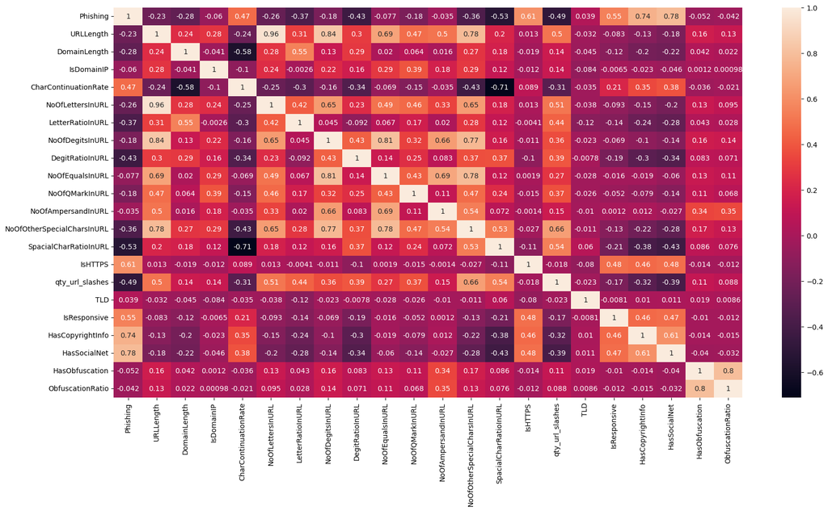

```python
import seaborn as sns
import matplotlib.pyplot as plt
plt.figure(figsize= (20, 10))
sns.heatmap(Phishing.corr(), annot=True)
```

```python
Phishing.head()
```

|  | Phishing | URLLength | DomainLength | IsDomainIP | CharContinuationRate | NoOfLettersInURL | LetterRatioInURL | NoOfDegitsInURL | DegitRatioInURL | NoOfEqualsInURL | ... | NoOfOtherSpecialCharsInURL | SpacialCharRatioInURL | IsHTTPS | qty_url_slashes | TLD | IsResponsive | HasCopyrightInfo | HasSocialNet | HasObfuscation | ObfuscationRatio |
| --- | --- | --- | --- | --- | --- | --- | --- | --- | --- | --- | --- | --- | --- | --- | --- | --- | --- | --- | --- | --- | --- |
| 0 | 0 | 29 | 22 | 0 | 1.0 | 21 | 0.724 | 0 | 0.0 | 0 | ... | 1 | 0.034 | 0 | 0 | 231 | 0 | 0 | 0 | 0 | 0.0 |
| 1 | 0 | 22 | 15 | 0 | 1.0 | 14 | 0.636 | 0 | 0.0 | 0 | ... | 1 | 0.045 | 0 | 0 | 231 | 0 | 0 | 0 | 0 | 0.0 |
| 2 | 0 | 28 | 20 | 0 | 1.0 | 19 | 0.679 | 0 | 0.0 | 0 | ... | 1 | 0.036 | 1 | 0 | 231 | 1 | 0 | 0 | 0 | 0.0 |
| 3 | 0 | 17 | 10 | 0 | 1.0 | 9 | 0.529 | 0 | 0.0 | 0 | ... | 1 | 0.059 | 0 | 0 | 231 | 0 | 0 | 0 | 0 | 0.0 |
| 4 | 0 | 31 | 23 | 0 | 1.0 | 22 | 0.710 | 0 | 0.0 | 0 | ... | 1 | 0.032 | 1 | 0 | 231 | 1 | 0 | 0 | 0 | 0.0 |

5 rows × 22 columns

[figure not shown]

```python
correlation_matrix = Phishing.corr()
top_10_corr=correlation_matrix['Phishing']
top_10_corr.sort_values()

top_10_corr=top_10_corr.drop('Phishing')
plt.figure(figsize=(10, 6))  # Optional: Adjust the size of the plot
plt.bar(top_10_corr.index, top_10_corr.values, color='skyblue')  # Bar chart with optional color

plt.title("Title of the Chart")  # Title of the chart
plt.xlabel("Variables")  # Label for the x-axis
plt.ylabel("Correlation Coefficient")  # Label for the y-axis

plt.xticks(rotation=45, ha='right')

# Display the chart
plt.tight_layout()
plt.show()
```

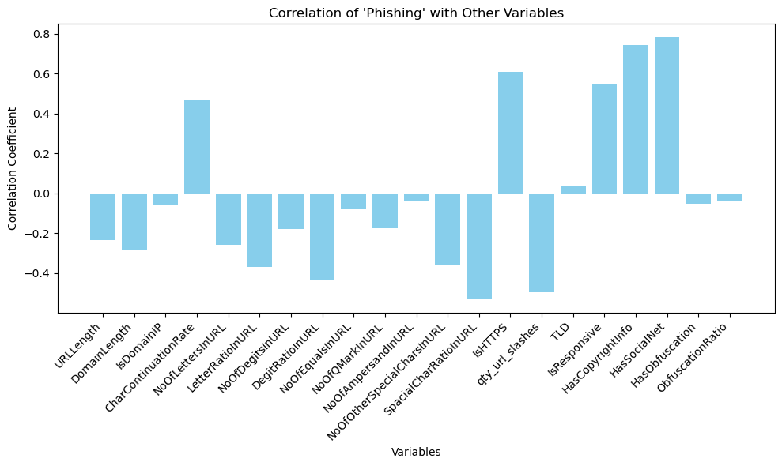

```python
correlations = Phishing.corr()
phishing_corr = correlations["Phishing"]


phishing_corr = phishing_corr.drop('Phishing')


plt.figure(figsize=(10, 6))
plt.bar(phishing_corr.index, phishing_corr.values, color='skyblue')


plt.title("Correlation of 'Phishing' with Other Variables")
plt.xlabel("Variables")
plt.ylabel("Correlation Coefficient")


plt.xticks(rotation=45, ha='right')

plt.tight_layout()
plt.show()
```

#### Automated EDA Report

```python
report = sv.analyze(Phishing)

report.show_notebook()
```

```
                                             |                                             | [  0%]   00:00 ->…
```

[interactive chart not shown]

## Model Implementation

```python
X = Phishing.drop(columns=['Phishing'])
y = Phishing['Phishing']
```

```python
X_train, X_test, y_train, y_test = train_test_split(X, y, test_size=0.2, random_state=42)
```

```python
X_train_new, X_val, y_train_new, y_val = train_test_split(X_train, y_train, test_size=0.2, random_state=42, stratify=y_train)
```

### 1. Logistic Regression Implementation

#### Feature Scaling

```python
scaler = StandardScaler()
X_train = scaler.fit_transform(X_train)
X_test = scaler.transform(X_test)
```

#### Initializing and training the model

```python
param_grid = {
    'C': [0.01, 0.1, 1, 10],
    'penalty': ['l1', 'l2'],
    'solver': ['liblinear'],
    'class_weight': ['balanced', None]
}

lr = LogisticRegression()

grid_search = GridSearchCV(estimator=lr, param_grid=param_grid, cv=5, scoring='accuracy', n_jobs=-1, verbose=1)

grid_search.fit(X_train, y_train)

lr = grid_search.best_estimator_

print(grid_search.best_params_)
```

```
Fitting 5 folds for each of 16 candidates, totalling 80 fits
{'C': 10, 'class_weight': None, 'penalty': 'l2', 'solver': 'liblinear'}
```

#### Predict on the test data

```python
y_pred = lr.predict(X_test)
y_pred_proba = lr.predict_proba(X_test)[:, 1]
```

#### Performance Evaluation Matrix

```python
accuracy = accuracy_score(y_test, y_pred)
precision = precision_score(y_test, y_pred)
recall = recall_score(y_test, y_pred)
r_squared=r2_score (y_test, y_pred)
f1 = f1_score(y_test, y_pred)
roc_auc = roc_auc_score(y_test, y_pred_proba)
```

```python
scores = cross_val_score(lr, X, y, cv=5)
```

#### Print Evaluation Matrix

```python
print("Model Evaluation Metrics:")
print(f"Accuracy: {accuracy:.2f}")
print(f"Precision: {precision:.2f}")
print(f"Recall: {recall:.2f}")
print(f"Rsquared: {r_squared:.2f}")
print(f"F1 Score: {f1:.2f}")
print(f"ROC-AUC Score: {roc_auc:.2f}")
mse = mean_squared_error(y_test, y_pred)
print("Test MSE:", mse)


print("Cross-validation accuracy:", scores.mean())
```

```
Model Evaluation Metrics:
Accuracy: 1.00
Precision: 1.00
Recall: 1.00
Rsquared: 0.99
F1 Score: 1.00
ROC-AUC Score: 1.00
Test MSE: 0.0019508471341631501
Cross-validation accuracy: 0.9951992196611463
```

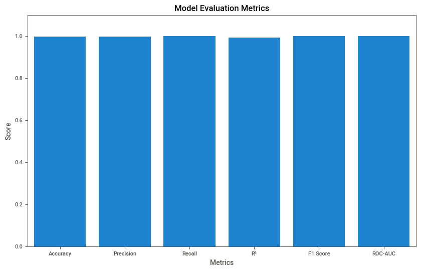

```python
metrics = ['Accuracy', 'Precision', 'Recall', 'R²', 'F1 Score', 'ROC-AUC']
values = [accuracy, precision, recall, r_squared, f1, roc_auc]

plt.figure(figsize=(10, 6))
sns.barplot(x=metrics, y=values)
plt.title('Model Evaluation Metrics')
plt.ylim(0, 1.1)  # Set y-axis to range from 0 to 1
plt.ylabel('Score')
plt.xlabel('Metrics')
plt.show()
```

```python
#Confusion Matrix
```

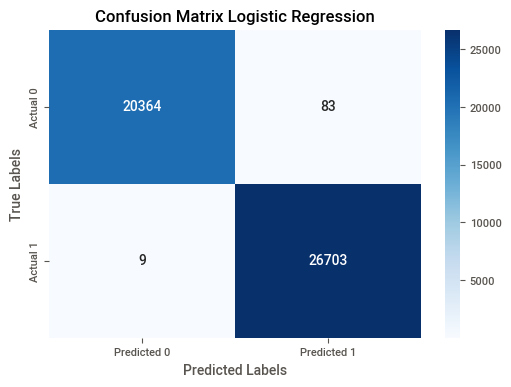

```python
conf_matrix = confusion_matrix(y_test, y_pred)
plt.figure(figsize=(6, 4))
sns.heatmap(conf_matrix, annot=True, fmt="d", cmap="Blues", xticklabels=["Predicted 0", "Predicted 1"], yticklabels=["Actual 0", "Actual 1"])
plt.xlabel("Predicted Labels")
plt.ylabel("True Labels")
plt.title("Confusion Matrix Logistic Regression")
plt.show()
```

#### ROC Curve

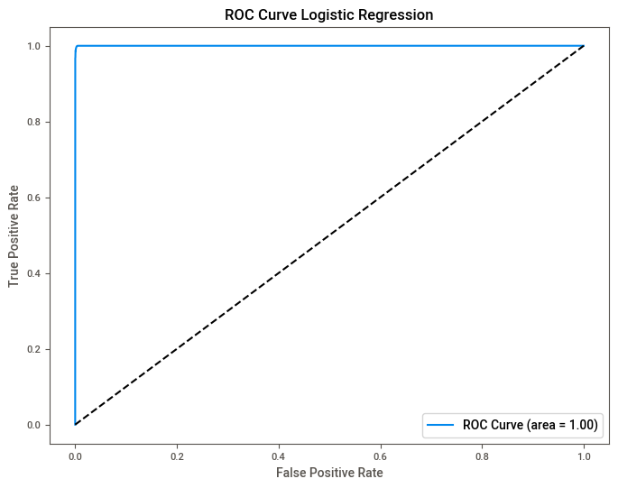

```python
fpr, tpr, thresholds = roc_curve(y_test, y_pred_proba)
plt.figure(figsize=(8, 6))
plt.plot(fpr, tpr, label=f"ROC Curve (area = {roc_auc:.2f})")
plt.plot([0, 1], [0, 1], 'k--')
plt.xlabel("False Positive Rate")
plt.ylabel("True Positive Rate")
plt.title("ROC Curve Logistic Regression")
plt.legend(loc="lower right")
plt.show()
```

```python
predictions_df = pd.DataFrame({'Actual': y_test, 'Predicted': y_pred})
print(predictions_df.head(100))
```

```
        Actual  Predicted
136221       0          0
56609        1          1
46393        1          1
129746       1          1
131464       1          1
...        ...        ...
42004        1          1
67861        1          1
58342        1          1
235081       0          0
36757        1          1

[100 rows x 2 columns]
```

### 2. Gradient Boosting Classifier

```python
X = Phishing.drop(columns=['Phishing'])
y = Phishing['Phishing']
X_train, X_test, y_train, y_test = train_test_split(X, y, test_size=0.2, random_state=0)
```

```python
scaler = StandardScaler()
X_train = scaler.fit_transform(X_train)
X_test = scaler.transform(X_test)
```

```python
#gb = GradientBoostingClassifier(n_estimators=100, learning_rate=0.1, max_depth=3, random_state=42)
param_grid = {
    'n_estimators': [50, 100, 200],
    'learning_rate': [0.01, 0.05, 0.1, 0.2],
    'max_depth': [3, 5, 7],
    'subsample': [0.8, 0.9, 1.0]
}

gb = GradientBoostingClassifier(random_state=42)

grid_search = GridSearchCV(estimator=gb, param_grid=param_grid, cv=5, scoring='accuracy', n_jobs=-1, verbose=1)

grid_search.fit(X_train, y_train)

gb = grid_search.best_estimator_
grid_search.best_estimator_
y_pred = gb.predict(X_test)
y_pred_proba = gb.predict_proba(X_test)[:, 1]
print(grid_search.best_params_)
```

```
Fitting 5 folds for each of 108 candidates, totalling 540 fits
{'learning_rate': 0.2, 'max_depth': 3, 'n_estimators': 200, 'subsample': 1.0}
```

```python
print("Number of mislabeled points out of a total %d points : %d"
      % (X_test.shape[0], (y_test != y_pred).sum()))
```

```
Number of mislabeled points out of a total 47159 points : 82
```

```python
accuracy = accuracy_score(y_test, y_pred)
precision = precision_score(y_test, y_pred)
recall = recall_score(y_test, y_pred)
r_squared=r2_score (y_test, y_pred)
f1 = f1_score(y_test, y_pred)
roc_auc = roc_auc_score(y_test, y_pred_proba)
```

```python
print("Model Evaluation Metrics:")
print(f"Accuracy: {accuracy:.2f}")
print(f"Precision: {precision:.2f}")
print(f"Recall: {recall:.2f}")
print(f"Rsquared: {r_squared:.2f}")
print(f"F1 Score: {f1:.2f}")
print(f"ROC-AUC Score: {roc_auc:.2f}")
mse = mean_squared_error(y_test, y_pred)
print("Test MSE:", mse)



scores = cross_val_score(gb, X, y, cv=5)  # 5-fold cross-validation
print("Cross-validation accuracy:", scores.mean())
```

```
Model Evaluation Metrics:
Accuracy: 1.00
Precision: 1.00
Recall: 1.00
Rsquared: 0.99
F1 Score: 1.00
ROC-AUC Score: 1.00
Test MSE: 0.0017387985326236773
Cross-validation accuracy: 0.982395725100193
```

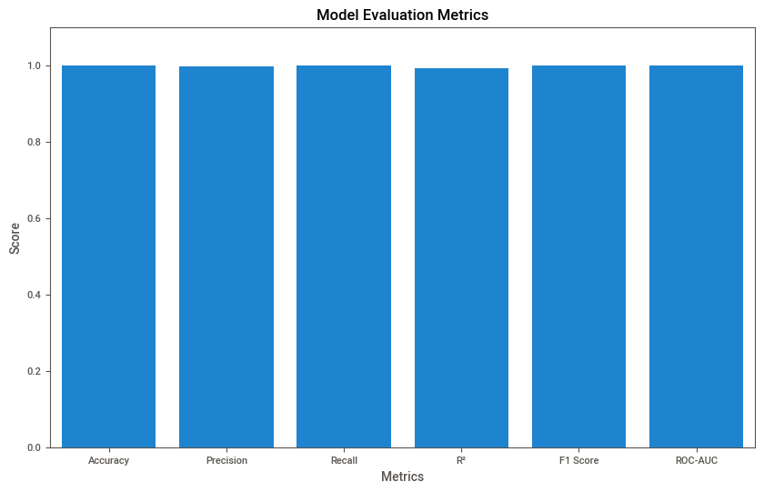

```python
metrics = ['Accuracy', 'Precision', 'Recall', 'R²', 'F1 Score', 'ROC-AUC']
values = [accuracy, precision, recall, r_squared, f1, roc_auc]

plt.figure(figsize=(10, 6))
sns.barplot(x=metrics, y=values)
plt.title('Model Evaluation Metrics')
plt.ylim(0, 1.1)  # Set y-axis to range from 0 to 1
plt.ylabel('Score')
plt.xlabel('Metrics')
plt.show()
```

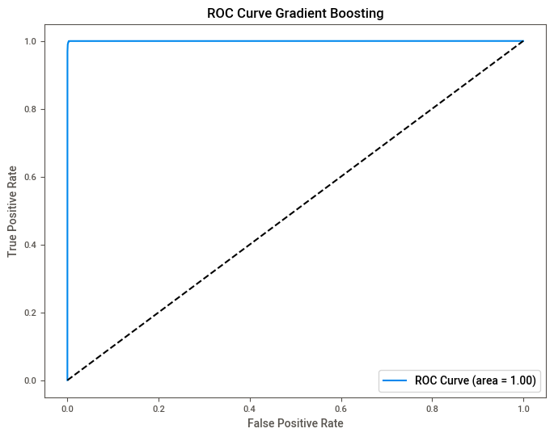

```python
fpr, tpr, thresholds = roc_curve(y_test, y_pred_proba)
plt.figure(figsize=(8, 6))
plt.plot(fpr, tpr, label=f"ROC Curve (area = {roc_auc:.2f})")
plt.plot([0, 1], [0, 1], 'k--')
plt.xlabel("False Positive Rate")
plt.ylabel("True Positive Rate")
plt.title("ROC Curve Gradient Boosting")
plt.legend(loc="lower right")
plt.show()
```

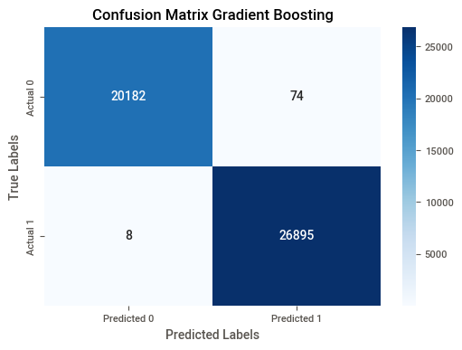

```python
conf_matrix = confusion_matrix(y_test, y_pred)
plt.figure(figsize=(6, 4))
sns.heatmap(conf_matrix, annot=True, fmt="d", cmap="Blues", xticklabels=["Predicted 0", "Predicted 1"], yticklabels=["Actual 0", "Actual 1"])
plt.xlabel("Predicted Labels")
plt.ylabel("True Labels")
plt.title("Confusion Matrix Gradient Boosting")
plt.show()
```

### 3. Random Forest Classifier

```python
X = Phishing.drop(columns=['Phishing'])
y = Phishing['Phishing']
X_train, X_test, y_train, y_test = train_test_split(X, y, test_size=0.2, random_state=0)


param_grid = {
    'n_estimators': [50, 100, 200],
    'max_depth': [2, 5, 10],
    'min_samples_split': [2, 5, 10],
    'min_samples_leaf': [1, 2, 4],
    'bootstrap': [True, False]
}

rfc = RandomForestClassifier(random_state=0)

grid_search = GridSearchCV(estimator=rfc, param_grid=param_grid, cv=5, scoring='accuracy', n_jobs=-1, verbose=1)

grid_search.fit(X_train, y_train)

rfc = grid_search.best_estimator_

print(grid_search.best_params_)
```

```
Fitting 5 folds for each of 162 candidates, totalling 810 fits
{'bootstrap': False, 'max_depth': 10, 'min_samples_leaf': 2, 'min_samples_split': 2, 'n_estimators': 50}
```

```python
y_pred=rfc.predict(X_test)
y_pred_proba = rfc.predict_proba(X_test)[:, 1]
```

```python
print("Number of mislabeled points out of a total %d points : %d"
      % (X_test.shape[0], (y_test != y_pred).sum()))
```

```
Number of mislabeled points out of a total 47159 points : 112
```

```python
accuracy = accuracy_score(y_test, y_pred)
precision = precision_score(y_test, y_pred)
recall = recall_score(y_test, y_pred)
r_squared=r2_score (y_test, y_pred)
f1 = f1_score(y_test, y_pred)
roc_auc = roc_auc_score(y_test, y_pred_proba)
```

```python
print("Model Evaluation Metrics:")
print(f"Accuracy: {accuracy:.2f}")
print(f"Precision: {precision:.2f}")
print(f"Recall: {recall:.2f}")
print(f"Rsquared: {r_squared:.2f}")
print(f"F1 Score: {f1:.2f}")
print(f"ROC-AUC Score: {roc_auc:.2f}")
mse = mean_squared_error(y_test, y_pred)
print("Test MSE:", mse)


scores = cross_val_score(rfc, X, y, cv=5)  # 5-fold cross-validation
print("Cross-validation accuracy:", scores.mean())
```

```
Model Evaluation Metrics:
Accuracy: 1.00
Precision: 1.00
Recall: 1.00
Rsquared: 0.99
F1 Score: 1.00
ROC-AUC Score: 1.00
Test MSE: 0.0023749443372420957
Cross-validation accuracy: 0.9659322716766681
```

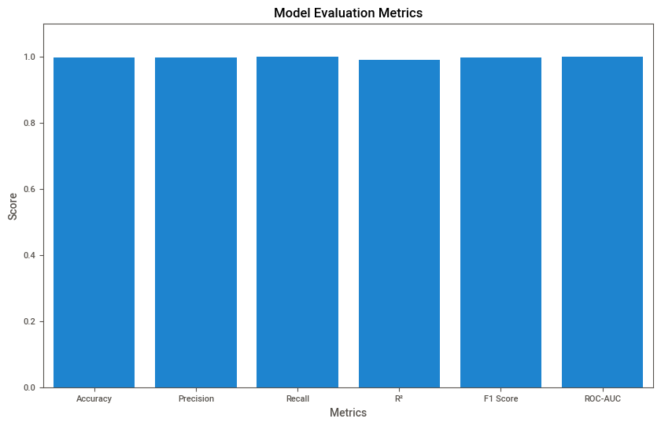

```python
metrics = ['Accuracy', 'Precision', 'Recall', 'R²', 'F1 Score', 'ROC-AUC']
values = [accuracy, precision, recall, r_squared, f1, roc_auc]

plt.figure(figsize=(10, 6))
sns.barplot(x=metrics, y=values)
plt.title('Model Evaluation Metrics')
plt.ylim(0, 1.1)  # Set y-axis to range from 0 to 1
plt.ylabel('Score')
plt.xlabel('Metrics')
plt.show()
```

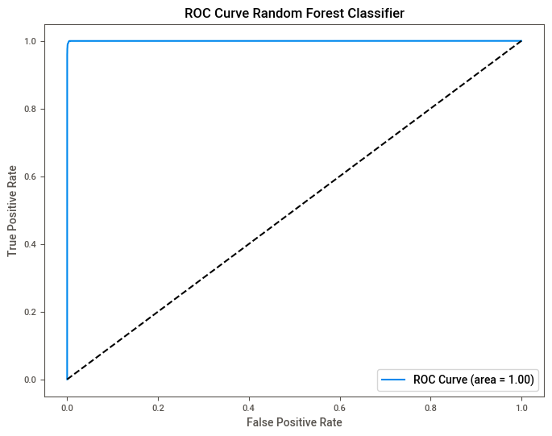

```python
fpr, tpr, thresholds = roc_curve(y_test, y_pred_proba)
plt.figure(figsize=(8, 6))
plt.plot(fpr, tpr, label=f"ROC Curve (area = {roc_auc:.2f})")
plt.plot([0, 1], [0, 1], 'k--')
plt.xlabel("False Positive Rate")
plt.ylabel("True Positive Rate")
plt.title("ROC Curve Random Forest Classifier")
plt.legend(loc="lower right")
plt.show()
```

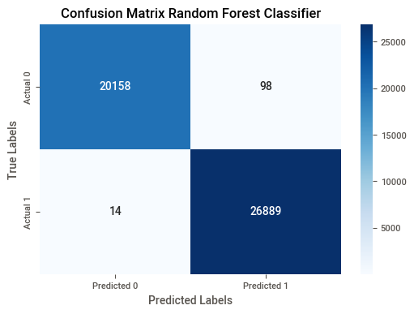

```python
conf_matrix = confusion_matrix(y_test, y_pred)
plt.figure(figsize=(6, 4))
sns.heatmap(conf_matrix, annot=True, fmt="d", cmap="Blues", xticklabels=["Predicted 0", "Predicted 1"], yticklabels=["Actual 0", "Actual 1"])
plt.xlabel("Predicted Labels")
plt.ylabel("True Labels")
plt.title("Confusion Matrix Random Forest Classifier")
plt.show()
```

### Decision Tree Classifier

```python
X = Phishing.drop(columns=['Phishing'])
y = Phishing['Phishing']

X_train, X_test, y_train, y_test = train_test_split(X, y, test_size=0.2, random_state=42)
```

```python
scaler = StandardScaler()
X_train = scaler.fit_transform(X_train)
X_test = scaler.transform(X_test)

param_grid = {
    'max_depth': [3, 5, 10],
    'min_samples_split': [2, 5, 10],
    'min_samples_leaf': [1, 2, 4],
    'criterion': ['gini', 'entropy']
}

dt = DecisionTreeClassifier(random_state=42)

grid_search = GridSearchCV(estimator=dt, param_grid=param_grid, cv=5, scoring='accuracy', n_jobs=-1, verbose=1)

grid_search.fit(X_train, y_train)

dt = grid_search.best_estimator_
print(grid_search.best_params_)
```

```
Fitting 5 folds for each of 54 candidates, totalling 270 fits
{'criterion': 'entropy', 'max_depth': 10, 'min_samples_leaf': 1, 'min_samples_split': 2}
```

```python
y_pred = dt.predict(X_test)
y_pred_proba = dt.predict_proba(X_test)[:, 1]
```

```python
print("Number of mislabeled points out of a total %d points : %d"
      % (X_test.shape[0], (y_test != y_pred).sum()))
```

```
Number of mislabeled points out of a total 47159 points : 96
```

```python
accuracy = accuracy_score(y_test, y_pred)
precision = precision_score(y_test, y_pred)
recall = recall_score(y_test, y_pred)
r_squared=r2_score (y_test, y_pred)
f1 = f1_score(y_test, y_pred)
roc_auc = roc_auc_score(y_test, y_pred_proba)
```

```python
print("Model Evaluation Metrics:")
print(f"Accuracy: {accuracy:.2f}")
print(f"Precision: {precision:.2f}")
print(f"Recall: {recall:.2f}")
print(f"Rsquared: {r_squared:.2f}")
print(f"F1 Score: {f1:.2f}")
print(f"ROC-AUC Score: {roc_auc:.2f}")
mse = mean_squared_error(y_test, y_pred)
print("Test MSE:", mse)


scores = cross_val_score(dt, X, y, cv=5)  # 5-fold cross-validation
print("Cross-validation accuracy:", scores.mean())
```

```
Model Evaluation Metrics:
Accuracy: 1.00
Precision: 1.00
Recall: 1.00
Rsquared: 0.99
F1 Score: 1.00
ROC-AUC Score: 1.00
Test MSE: 0.0020356665747789395
Cross-validation accuracy: 0.9668737674675036
```

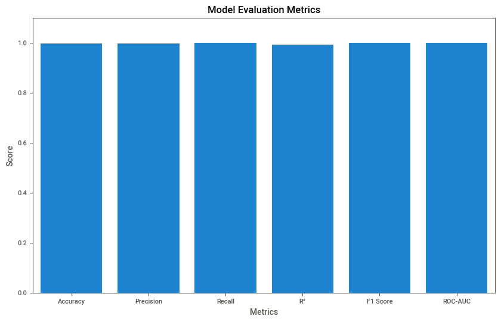

```python
metrics = ['Accuracy', 'Precision', 'Recall', 'R²', 'F1 Score', 'ROC-AUC']
values = [accuracy, precision, recall, r_squared, f1, roc_auc]

plt.figure(figsize=(10, 6))
sns.barplot(x=metrics, y=values)
plt.title('Model Evaluation Metrics')
plt.ylim(0, 1.1)  # Set y-axis to range from 0 to 1
plt.ylabel('Score')
plt.xlabel('Metrics')
plt.show()
```

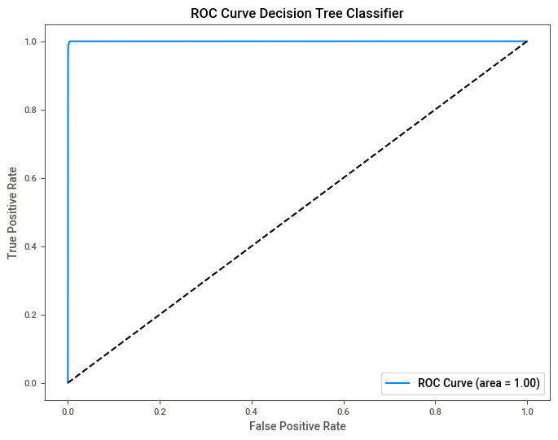

```python
fpr, tpr, thresholds = roc_curve(y_test, y_pred_proba)
plt.figure(figsize=(8, 6))
plt.plot(fpr, tpr, label=f"ROC Curve (area = {roc_auc:.2f})")
plt.plot([0, 1], [0, 1], 'k--')
plt.xlabel("False Positive Rate")
plt.ylabel("True Positive Rate")
plt.title("ROC Curve Decision Tree Classifier")
plt.legend(loc="lower right")
plt.show()
```

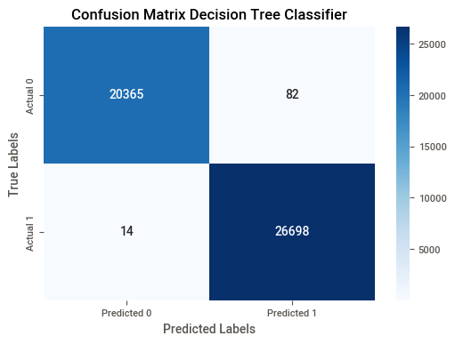

```python
conf_matrix = confusion_matrix(y_test, y_pred)
plt.figure(figsize=(6, 4))
sns.heatmap(conf_matrix, annot=True, fmt="d", cmap="Blues", xticklabels=["Predicted 0", "Predicted 1"], yticklabels=["Actual 0", "Actual 1"])
plt.xlabel("Predicted Labels")
plt.ylabel("True Labels")
plt.title("Confusion Matrix Decision Tree Classifier")
plt.show()
```

# Conclusion

The key features selected for model training—such as domain reputation, URL structure, and the presence of suspicious characters in the link—proved to be highly relevant in distinguishing between phishing and non-phishing emails. These variables were either strongly positively or negatively correlated with the likelihood of an email being a phishing attempt, providing clear signals that the models could leverage to make accurate predictions. This indicates that machine learning can effectively capture subtle patterns in email characteristics that might otherwise be difficult for traditional methods to detect.

As cybersecurity threats continue to evolve, the use of machine learning to detect phishing emails offers a scalable and adaptive approach to enhancing security infrastructure. This project demonstrates that machine learning models, when properly trained with relevant and well-curated features, can significantly improve phishing detection, providing a valuable tool for organizations looking to defend against increasingly sophisticated phishing campaigns. Furthermore, the results from this project serve as a foundational step in developing more advanced systems capable of addressing a broader range of cybersecurity threats in real-time.

In conclusion, while this project serves as an initial exploration into using machine learning for spam and phishing detection, the promising results lay the groundwork for future enhancements. More granular features, such as email content analysis, user behavior, and multi-modal approaches combining both email and website data, could be incorporated to improve detection accuracy even further. As both spam and phishing attacks become more sophisticated, the integration of machine learning models into automated cybersecurity systems offers a proactive and efficient means of safeguarding users and organizations from these growing threats.